# Activity Tracker - Reproducible research

Gabe Boer

9 oktober 2017

Header settings saying that code always needs to be shown.

```r
knitr::opts_chunk$set(echo = TRUE)
#setwd("~/Coursera R folder")
```

## Loading and preprocessing the data

### 1. Reading the data file

This is an R Markdown document for the Reproducible Research assignment. The first step is to manually manipulate the csv file in notepad. Removing all quotes (“”). Didn’t find a proper way in R to do it. The second step is reading the data from csv file.

```r
act <- read.csv("activity.csv", sep = ",", header = FALSE, skip = 1, quote = "")

names(act)[1] <- "Steps"
names(act)[2] <- "Date"
names(act)[3] <- "Interval"
```

### 2. Process/Transform the data (if necessary) into a format more suitable for your analysis

```r
#act$Steps <- as.numeric(act$Steps)
act$Date <- as.Date(act$Date, format = "%Y-%m-%d")
```

A quick summary of the loaded data will give:

```
##      Steps             Date               Interval
##  Min.   :  0.00   Min.   :2012-10-01   Min.   :   0.0
##  1st Qu.:  0.00   1st Qu.:2012-10-16   1st Qu.: 588.8
##  Median :  0.00   Median :2012-10-31   Median :1177.5
##  Mean   : 37.38   Mean   :2012-10-31   Mean   :1177.5
##  3rd Qu.: 12.00   3rd Qu.:2012-11-15   3rd Qu.:1766.2
##  Max.   :806.00   Max.   :2012-11-30   Max.   :2355.0
##  NA's   :2304
```

## What is mean total number of steps taken per day

### 1. Number of steps calculation

```r
totalsteps <- aggregate(Steps~Date, act, FUN = sum, na.action = na.omit)
#head(totalsteps, 10)
summary(totalsteps)
```

```
##       Date                Steps
##  Min.   :2012-10-02   Min.   :   41
##  1st Qu.:2012-10-16   1st Qu.: 8841
##  Median :2012-10-29   Median :10765
##  Mean   :2012-10-30   Mean   :10766
##  3rd Qu.:2012-11-16   3rd Qu.:13294
##  Max.   :2012-11-29   Max.   :21194
```

### 2. plot in histogram

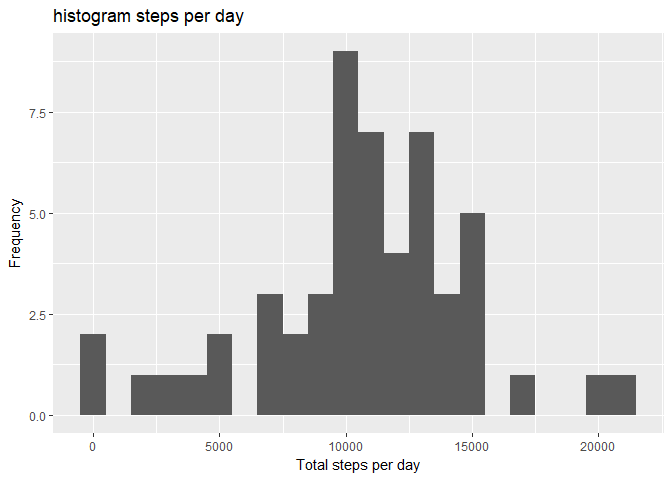

```r
library(ggplot2)
qplot(totalsteps$Steps, geom = "histogram",
      binwidth = 1000,

      xlab = "Total steps per day",
      ylab = "Frequency",
      main = "histogram steps per day"
     )
```

### 3a. the mean of the total number of steps taken per day

```r
mean(totalsteps$Steps)
```

```
## [1] 10766.19
```

### 3b. the median of the total number of steps taken per day

```r
median(totalsteps$Steps)
```

```
## [1] 10765
```

## What is the average daily activity pattern?

### 1. Make a time series plot of the 5-min interval (x) and the avg number of steps (y)

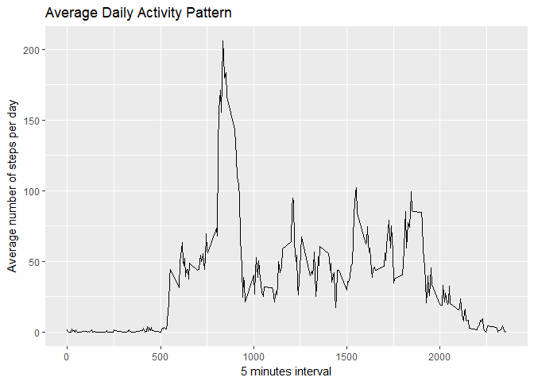

```r
min5 <- aggregate(Steps~Interval, data = act, FUN = mean, na.rm = TRUE)

ggplot(
        data = min5,
        aes(
                x = Interval,
                y = Steps)) +
        geom_line() +
        xlab("5 minutes interval") +
        ylab("Average number of steps per day") +
        ggtitle("Average Daily Activity Pattern")
```

### 2. which 5 min interval contains max number of steps?

```r
max <- min5$Interval[which.max(min5$Steps)]
max
```

```
## [1] 835
```

## Imputing missing values

```r
summary(act)
```

```
##      Steps             Date               Interval
##  Min.   :  0.00   Min.   :2012-10-01   Min.   :   0.0
##  1st Qu.:  0.00   1st Qu.:2012-10-16   1st Qu.: 588.8
##  Median :  0.00   Median :2012-10-31   Median :1177.5
##  Mean   : 37.38   Mean   :2012-10-31   Mean   :1177.5
##  3rd Qu.: 12.00   3rd Qu.:2012-11-15   3rd Qu.:1766.2
##  Max.   :806.00   Max.   :2012-11-30   Max.   :2355.0
##  NA's   :2304
```

Showing that in ‘dimension Steps’ there are 2.304 rows with value NA.

### 2. Devise strategy for filling the missing values in data set

```r
# make copy of original df
act2 <- act

# NA records wegschrijven
act2na <- is.na(act2$Steps)

# determine average of interval without na records
intavg <- tapply(act2$Steps, act2$Interval, mean, na.rm=TRUE, simplify = TRUE)

# add values of average to the na records
act2$Steps[act2na] <- intavg[as.character(act2$Interval[act2na])]
head(act2, 10)
```

```
##        Steps       Date Interval
## 1  1.7169811 2012-10-01        0
## 2  0.3396226 2012-10-01        5
## 3  0.1320755 2012-10-01       10
## 4  0.1509434 2012-10-01       15
## 5  0.0754717 2012-10-01       20
## 6  2.0943396 2012-10-01       25
## 7  0.5283019 2012-10-01       30
## 8  0.8679245 2012-10-01       35
## 9  0.0000000 2012-10-01       40
## 10 1.4716981 2012-10-01       45
```

### 4. Make histogram (7)

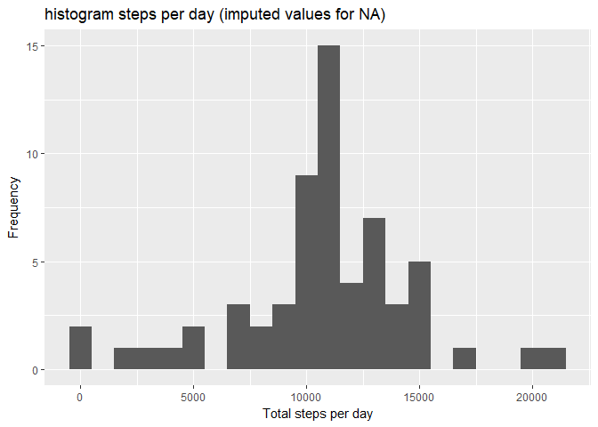

```r
totstepsim <- aggregate(Steps~Date, act2, FUN = sum)
qplot(totstepsim$Steps, geom = "histogram",
      binwidth = 1000,

      xlab = "Total steps per day",
      ylab = "Frequency",
      main = "histogram steps per day (imputed values for NA)"
     )
```

## Are there differences in activity patterns between weekdays and weekends?

### 1. Create a new factor variable in dataset

```r
# df with imputed values is starting point, make copy
act3 <- act2

# create weekdays column using function weekdays()
act3$wkd <- weekdays(act3$Date)

# create column where is stated weekday or weekend using ifelse(test, yes, no)
act3$work <- ifelse(act3$wkd == "zaterdag" | act3$wkd == "zondag", "weekend", "weekday")
```

### 2. Make a panel plot containing time series plot (8)

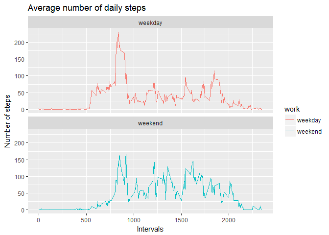

```r
min52 <- aggregate(Steps~Interval + work, data = act3, FUN = mean)

ggplot(
        data = min52,
        aes(    x = Interval,
                y = Steps,
                color = work)) +
        #facet_grid(work~.) +
        facet_wrap(~work, ncol =1, nrow = 2) +
        geom_line() +
        labs(title="Average number of daily steps",
             x="Intervals",
        y="Number of steps")
```